# Address Data Mismatch Analysis

2025-03-14

# 1 Introduction

The list of residential addresses showed that we had 376k homes, but census data revealed that there were 342k households. This script aims to understand why there are 10% more homes than households in Leeds by considering:

1. Vacant properties in our property dataset that could explain more homes than households.
2. Residential addresses included in the property dataset that a typical household would not reside in e.g. hotels and student accommodations/

# 2 Vacant Properties

## 2.1 Load and clean data

```r
# Read vacant property data
vacant_property_data <- read_excel("raw_data/numberofvacantdwellingsandsecondhomes.xlsx",
                                   sheet = "1c") %>%
  rename(
    lsoa21cd = 1,
    lsoa_name = 2,
    vacant_dwellings = 3,
    second_home = 4
  )

# Filter only LSOAs in Leeds
vacant_property_data <- vacant_property_data %>%
  filter(str_detect(lsoa_name, "Leeds"))

# Replace "c" (less than 10) with 0
vacant_property_data <- vacant_property_data %>%
  mutate(
    vacant_dwellings = ifelse(vacant_dwellings == "c", 0, vacant_dwellings),
    second_home = ifelse(second_home == "c", 0, second_home)
  )

# Calculate total vacant properties
vacant_property_data <- vacant_property_data %>%
  group_by(lsoa21cd, lsoa_name) %>%
  summarise(
    vacant_dwellings = sum(as.numeric(vacant_dwellings), na.rm = TRUE),
    second_home = sum(as.numeric(second_home), na.rm = TRUE),
    total_vacant = vacant_dwellings + second_home,
    .groups = "drop"
  )
```

## 2.2 How many vacant properties are in Leeds?

```r
# Calculate total number of vacant properties
total_vacant_properties <- sum(vacant_property_data$total_vacant, na.rm = TRUE)
print(total_vacant_properties)
```

```
## [1] 15610
```

The minimum number of vacant properties in Leeds is **15,610**, which explains about 50% of the discrepancy between households and homes.

## 2.3 Compare with total properties in Leeds

```r
# Read full property dataset
property_data <- read.csv("processed_data/full_address_data.csv")

# Count number of properties per LSOA
lsoa_counts <- property_data %>%
  count(lsoa21cd, name = "property_count")

# Merge property count with vacant property data
vacant_property_data <- vacant_property_data %>%
  left_join(lsoa_counts, by = "lsoa21cd")

# Compute proportion of vacant properties per LSOA
vacant_property_data <- vacant_property_data %>%
  mutate(vacant_proportion = 100 * total_vacant / property_count)
```

## 2.4 Distribution of vacant properties

The histogram below shows the distribution of vacant properties as a percentage of total properties across different LSOAs in Leeds.

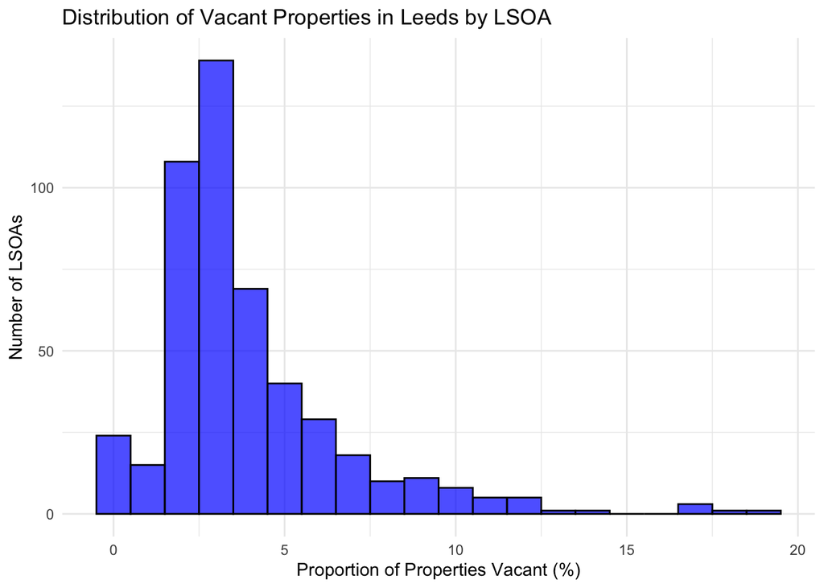

Note: This analysis underestimates the number of vacant properties, as LSOAs with 0 to 9 vacant properties are reported as ‘c’ (concealed). Since the exact values are unknown, we assume them to be 0.

# 3 Unconvential residential addresses

## 3.1 Load and Clean data

```r
# Read full property dataset
property_data <- read.csv("processed_data/full_address_data.csv") %>%
  mutate(addr1 = ifelse(addr2 == "1 RUTLAND MOUNT", addr2, addr1)) %>%
  mutate(addr1 = ifelse(addr2 == "15 WOODHOUSE SQUARE", addr2, addr1)) %>%
  mutate(addr1 = ifelse(addr2 == "93 PORTLAND CRESCENT", addr2, addr1))
```

## 3.2 Create a list of hotels and student accommodations to search for:

```r
hotel_keywords <- c(
  "HOTEL",
  "HOSTEL",
  "IBIS",
  "TRAVELODGE",
  "PREMIER INN",
  "HOLIDAY INN",
  "MERCURE",
  "NOVOTEL",
  "EASYHOTEL",
  "ROOMZZZ",
  "RAMADA",
  "B&B",
  "B & B",
  "THE DAYS INN",
  "GUEST",
  "RUSSELL SCOTT BACKPACKERS",
  "OASIS RESIDENCE",
  "THE PLAZA",
  "BRIGGATE STUDIOS",
  "SKY PLAZA",
  "SYMONS HOUSE",
  "WOODHOUSE FLATS",
  "AUSTIN HALL",
  "THE FOUNDRY",
  "OXLEY HALL",
  "1 RUTLAND MOUNT",
  "15 WOODHOUSE SQUARE",
  "PORTLAND CRESCENT",
  "THE TANNERY",
  "THE TERRY FROST BUILDING",
  "CONCEPT PLACE",
  "THE REFINERY",
  "HEPWORTH LODGE",
  "THE PRIORY",
  "WHITE ROSE VIEW",
  "BROADCASTING TOWER",
  "CITYSIDE",
  "HORTON HOUSE",
  "ARENA VILLAGE"
)

# Compile hotel data
hotel_data <- property_data %>%
  filter(str_detect(str_to_upper(addr1), str_c(hotel_keywords, collapse = "|")))
```

## 3.3 Special Case of inns

It’s difficult to select inns within the property dataset - some street names may have the term “Inn” even if they are residential addresses. To deal with this, properties with the term “Inn” are only selected if they don’t have a door number:

```r
inn_data <- property_data %>%
  filter(str_detect(str_to_upper(addr1), "\\bINN\\b") & is.na(door_number))

inn_data %>%
  slice_sample(n = 10) %>%
  select(addr1, addr2)
```

```
##               addr1            addr2
## 1       PREMIER INN       SELBY ROAD
## 2        REGENT INN 17 REGENT STREET
## 3           NEW INN   33 TOWN STREET
## 4     NAGS HEAD INN STONEBRIDGE LANE
## 5           NEW INN    ALBERT SQUARE
## 6      OLD TREE INN      HIGH STREET
## 7           NEW INN    CHURCH STREET
## 8  THE OLD STAR INN      MAIN STREET
## 9     THE MARSH INN     70 UPPERMOOR
## 10         SHIP INN         BRIGGATE
```

```r
# Reinsert Inn data to hotel data
hotel_data <- bind_rows(hotel_data, inn_data)

# Remove duplicates
hotel_data <- hotel_data %>%
  distinct()
```

## 3.4 Aggregate hotel data at LSOA level

```r
# Count number of hotels and student accommoadtions per LSOA
hotel_counts <- hotel_data %>%
  count(lsoa21cd, name = "hotel_count")

# Count number of properties per LSOA
lsoa_counts <- property_data %>%
  count(lsoa21cd, name = "property_count")

# Merge hotel counts with property data
hotel_property_data <- lsoa_counts %>%
  left_join(hotel_counts, by = "lsoa21cd")

# Replace NA columns with 0
hotel_property_data <- hotel_property_data %>%
  mutate(hotel_count = ifelse(is.na(hotel_count), 0, hotel_count))

# Compute proportion of hotels and student accommodations per LSOA
hotel_property_data <- hotel_property_data %>%
  mutate(hotel_proportion = 100 * hotel_count / property_count)
```

## 3.5 How many hotels and student accommodations are in Leeds?

```r
# Calculate total number of vacant properties (hotels)
hotel_count <- sum(hotel_counts$hotel_count, na.rm = TRUE)
print(hotel_count)
```

```
## [1] 3444
```

```r
# Calculate total number of properties
total_properties <- nrow(property_data)
print(total_properties)
```

```
## [1] 376146
```

```r
# Proportion of hotels in property data
prop_hotels <- (hotel_count / total_properties) * 100
```

Within our address data, there are a total of **3,444** hotels and student accommodations in Leeds. This takes up **0.9156019** percent of properties in Leeds.

## 3.6 Distribution of hotels

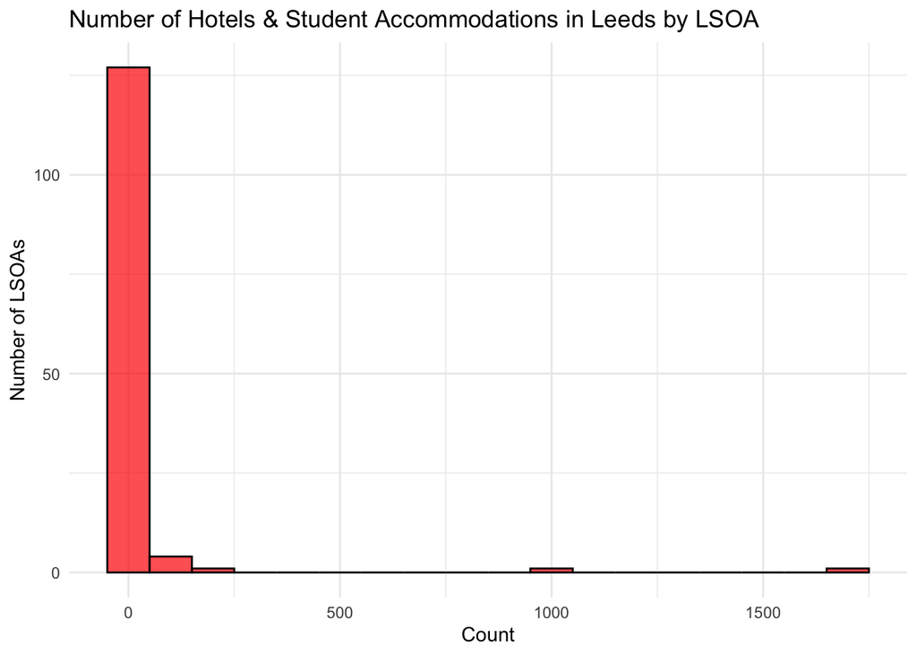

# 4 Correcting the mismatch

Now we observe how the mismatch in address and household has changed after adjusting for hotels and vacant properties.

## 4.1 Load and clean data

```r
household_count <- read.csv("processed_data/leeds_census_data_2021_lsoa.csv") %>%
  select(lsoa21cd, total_number_of_households)

# Merge with hotel and vacant property data
household_count <- household_count %>%
  left_join(hotel_property_data, by = "lsoa21cd") %>%
  left_join(vacant_property_data, by = "lsoa21cd") %>%
  mutate(
    property_count = coalesce(property_count.x, property_count.y),
    mismatched_addr = hotel_count + total_vacant,
    remaining_addr = property_count - mismatched_addr
  ) %>%
  select(lsoa21cd, property_count, hotel_count, total_vacant, total_number_of_households, mismatched_addr, remaining_addr)
```

## 4.2 Proportion of addresses remaining

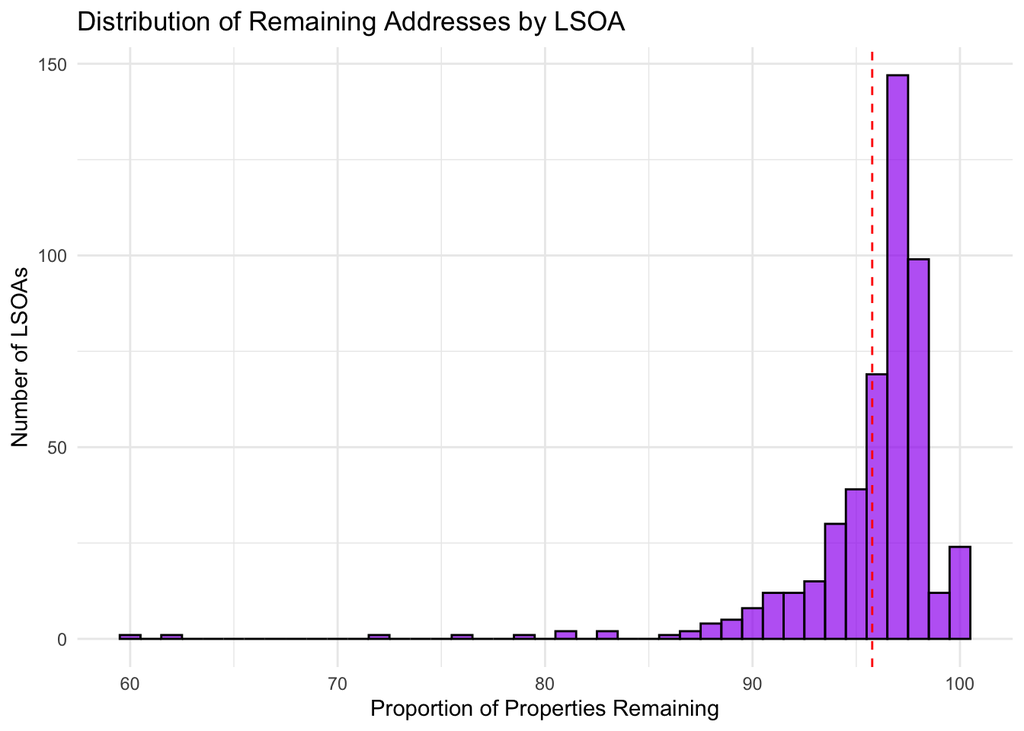

```r
household_count <- household_count %>%
mutate(prop_remaining = 100 * remaining_addr / property_count)

mean_prop_remaining <- mean(household_count$prop_remaining, na.rm = TRUE)

ggplot(household_count, aes(x = prop_remaining)) +
    geom_histogram(binwidth = 1, fill = "purple", color = "black", alpha = 0.7) +
    geom_vline(aes(xintercept = mean_prop_remaining),
               color = "red", linetype = "dashed") +
    labs(title = "Distribution of Remaining Addresses by LSOA",
         x = "Proportion of Properties Remaining",
         y = "Number of LSOAs") +
    theme_minimal()
```

On average **95.7704** percent of properties are kept after removing vacant properties and hotels.

## 4.3 Distribution of address mismatch by adjusting for vacant properties and hotels

The address mismatch at the LSOA level is defined as:

$$mismatch = 100 \times \left( \frac{addresses}{households} - 1 \right)$$

A positive mismatch consequently means that there are more addresses than households, and negative negative mismatch would occur when there are more households than addresses.

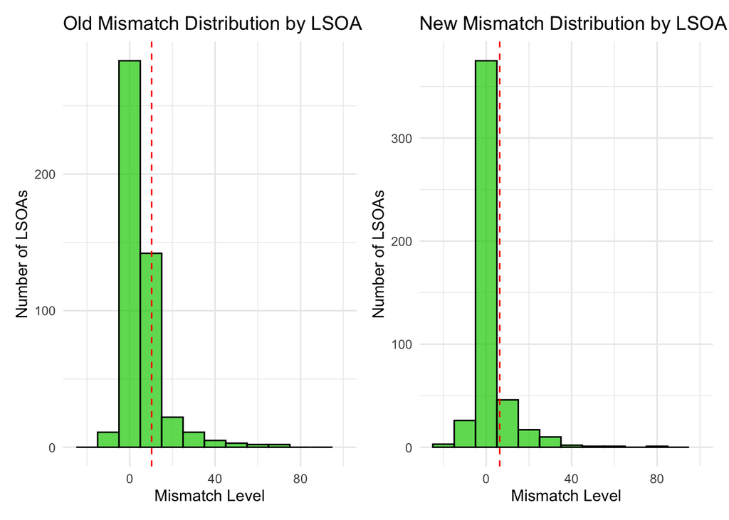

```r
household_count <- household_count %>%
  mutate(mismatch_old = 100 * ((property_count / total_number_of_households) -1)) %>%
  mutate(mismatch_new = 100 * ((remaining_addr / total_number_of_households) -1))

mean_mismatch_old <- mean(abs(household_count$mismatch_old))
mean_mismatch_new <- mean(abs(household_count$mismatch_new))

# Old Mismatch Plot with Vertical Line and X-axis Limits
mismatch_old_plot <- ggplot(household_count, aes(x = mismatch_old)) +
    geom_histogram(binwidth = 10, fill = "green3", color = "black", alpha = 0.7) +
    geom_vline(aes(xintercept = mean_mismatch_old), color = "red", linetype = "dashed") +
    scale_x_continuous(limits = c(-25, 100)) +  # Set X-axis range from 0 to 100
    labs(title = "Old Mismatch Distribution by LSOA",
         x = "Mismatch Level",
         y = "Number of LSOAs") +
    theme_minimal()

# New Mismatch Plot with Vertical Line and X-axis Limits
mismatch_new_plot <- ggplot(household_count, aes(x = mismatch_new)) +
    geom_histogram(binwidth = 10, fill = "green3", color = "black", alpha = 0.7) +
    geom_vline(aes(xintercept = mean_mismatch_new), color = "red", linetype = "dashed") +
    scale_x_continuous(limits = c(-25, 100)) +  # Set X-axis range from 0 to 100
    labs(title = "New Mismatch Distribution by LSOA",
         x = "Mismatch Level",
         y = "Number of LSOAs") +
    theme_minimal()

# Arrange side by side
mismatch_old_plot + mismatch_new_plot
```

By adjusting for vacant properties mean LSOA-mismatch level was previously at **10.30755** and it has now fallen to **6.303467**, effectively it has reduced by **39%**.

## 4.4 Distribution of address mismatch by only adjusting for hotels and student accommodations

We do not have data on which specific properties are vacant in an LSOA - we only have data on the number of vacant properties. Given this, it is important to also consider the reduction in address mismatch purely from unconventional residential addresses:

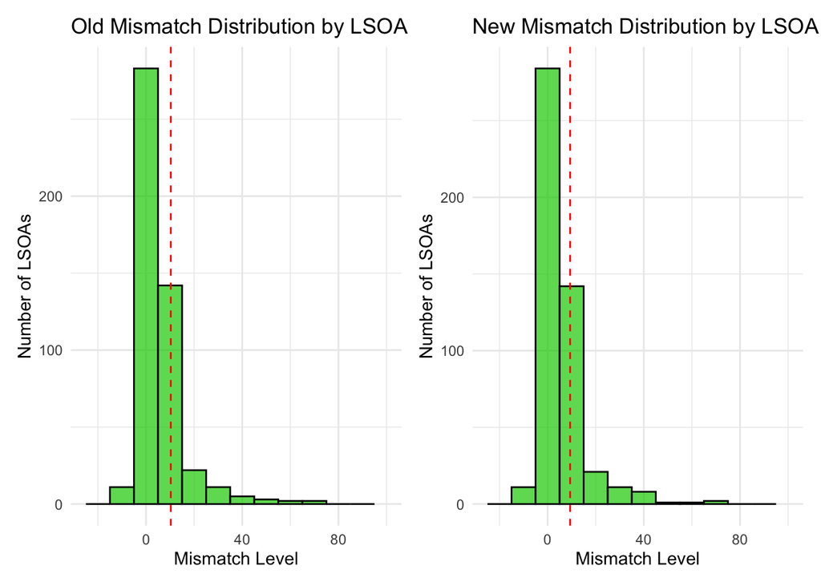

```r
household_count <- household_count %>%
  mutate(remaining_addr_hotel = property_count - hotel_count) %>%
  mutate(hotel_mismatch_new = 100 * ((remaining_addr_hotel / total_number_of_households) -1))

mean_hotel_mismatch_new <- mean(abs(household_count$hotel_mismatch_new))

# Old Mismatch Plot with Vertical Line and X-axis Limits
hotel_mismatch_old_plot <- ggplot(household_count, aes(x = mismatch_old)) +
    geom_histogram(binwidth = 10, fill = "green3", color = "black", alpha = 0.7) +
    geom_vline(aes(xintercept = mean_mismatch_old), color = "red", linetype = "dashed") +
    scale_x_continuous(limits = c(-25, 100)) +  # Set X-axis range from 0 to 100
    labs(title = "Old Mismatch Distribution by LSOA",
         x = "Mismatch Level",
         y = "Number of LSOAs") +
    theme_minimal()

# New Mismatch Plot with Vertical Line and X-axis Limits
hotel_mismatch_new_plot <- ggplot(household_count, aes(x = hotel_mismatch_new)) +
    geom_histogram(binwidth = 10, fill = "green3", color = "black", alpha = 0.7) +
    geom_vline(aes(xintercept = mean_hotel_mismatch_new), color = "red", linetype = "dashed") +
    scale_x_continuous(limits = c(-25, 100)) +  # Set X-axis range from 0 to 100
    labs(title = "New Mismatch Distribution by LSOA",
         x = "Mismatch Level",
         y = "Number of LSOAs") +
    theme_minimal()

# Arrange side by side
hotel_mismatch_old_plot + hotel_mismatch_new_plot
```

# 5 Key takeaways